# Weekly feeback

Simon Coburg; IMBRSea 20191199 - CCMAR a73216

23/04/2021

### Thesis “Seagrass domination over seaweeds in oligotrophic coastal ecosystems”

with supervisors: *[Ana Alexandre](https://www.ccmar.ualg.pt/users/aalexandre), [Carmen de los Santos](https://www.ccmar.ualg.pt/users/cbsantos) & [Rui Santos](https://www.ccmar.ualg.pt/users/rosantos), CCMAR*

*R script - [GitHub](https://github.com/NestaKobe/Uptake_rates)*

PRISMA protocol step **Eligibility**

*of full-text articles assessed for eligibility:* 344

### Exploratory data analysis

#### 1. Loading data and examine data structure

```r
# load SOURCES
data.sou  <- read_excel("~/Documents/IMBRSea/Thesis S4/Database uptake rate_23.04.2021.xlsx",
                        sheet="sources",na="NA",skip=3)

str(data.sou)
```

```
## tibble[,6] [40 × 6] (S3: tbl_df/tbl/data.frame)
##  $ study_id        : chr [1:40] "Alexandre et al. (2017)" "Aquilino et al. (2020)" "Barr et al. (2008)" "Barrow et al. (2015)" ...
##  $ publication_type: chr [1:40] "Journal article" "Journal article" "Journal article" "Journal article" ...
##  $ title           : chr [1:40] "Interactions between seagrasses and seaweeds during surge nitrogen acquisition determine interspecific competition" "Chaetomorpha linum in the bioremediation of aquaculture wastewater: Optimization of nutrient removal efficiency"| __truncated__ "Wave surge increas…
##  $ year            : num [1:40] 2017 2020 2008 2015 2014 ...
##  $ doi             : chr [1:40] "10.1038/s41598-017-13962-4" "10.1016/j.aquaculture.2020.735133" "10.3354/ab00079" "10.1515/bot-2014-0070" ...
##  $ annotations     : chr [1:40] NA NA NA NA ...
```

```r
names(data.sou)
```

```
## [1] "study_id"         "publication_type" "title"            "year"
## [5] "doi"              "annotations"
```

```r
# load ENVIRONMENTAL
data.env  <- read_excel("~/Documents/IMBRSea/Thesis S4/Database uptake rate_23.04.2021.xlsx",
                        sheet="environmental",na="NA",skip=3)
str(data.env)
```

```
## tibble[,26] [70 × 26] (S3: tbl_df/tbl/data.frame)
##  $ study_id          : chr [1:70] "Morris et al. (2008)" "Stapel et al. (1996)" "Stapel et al. (1996)" "Stapel et al. (1996)" ...
##  $ id_short          : chr [1:70] "Mor2008" "Sta1996a" "Sta1996a" "Sta1996b" ...
##  $ sample_location   : chr [1:70] "Santibañez, Cadiz" "Gusung Tailang, Spermode archipelago" "Gusung Tailang, Spermode archipelago" "Barang Lompo, Spermode archipelago" ...
##  $ sample_country    : chr [1:70] "Spain" "Indonesia" "Indonesia" "Indonesia" ...
##  $ sample_latitude   : num [1:70] 36.5 NA NA NA NA ...
##  $ sample_longitude  : num [1:70] -6.25 NA NA NA NA ...
##  $ sample_season     : chr [1:70] "Autumn" NA NA NA ...
##  $ watercol_nutrient : chr [1:70] NA "Ammonium" "Phosphate" "Ammonium" ...
##  $ watercol_mean     : num [1:70] NA 2.6 0.6 2.2 0.3 1 0.1 5 5 5 ...
##  $ watercol_stdev    : num [1:70] NA 1.9 0.3 1.5 0.21 0.5 0.04 NA NA NA ...
##  $ watercol_min_range: num [1:70] NA 0.6 0.3 0.8 0 0.2 0.1 NA NA NA ...
##  $ watercol_max_range: num [1:70] NA 5.4 1.1 5.3 1.2 1.6 0.2 NA NA NA ...
##  $ porewater_mean    : num [1:70] NA 136 0.92 60 5.5 106 5.4 NA NA NA ...
##  $ porewater_stdev   : num [1:70] NA 7 0.49 10 2.5 11 0 NA NA NA ...
##  $ porewater_min     : num [1:70] NA NA NA NA NA NA NA 12 0.2 12 ...
##  $ porewater_max     : num [1:70] NA NA NA NA NA NA NA 38 0.9 38 ...
##  $ water_salinity    : num [1:70] 31 NA NA NA NA NA NA NA NA NA ...
##  $ water_temp        : num [1:70] 16 28 28 28 28 28 28 14 14 14 ...
##  $ water_ammonia     : num [1:70] NA 30 30 30 30 30 30 NA NA NA ...
##  $ water_nitrate     : num [1:70] NA NA NA NA NA NA NA NA NA NA ...
##  $ water_phosphateq  : num [1:70] NA 5 5 5 5 5 5 NA NA NA ...
##  $ acclimation       : num [1:70] 2 NA NA NA NA NA NA NA NA NA ...
##  $ incubation        : num [1:70] NA 1 1 1 1 1 1 NA NA NA ...
##  $ lumination        : num [1:70] 200 NA NA NA NA NA NA 300 300 300 ...
##  $ photoperiod       : POSIXct[1:70], format: "1899-12-31 14:24:00" NA ...
##  $ annotations_env   : chr [1:70] NA NA NA NA ...
```

```r
names(data.env)
```

```
##  [1] "study_id"           "id_short"           "sample_location"
##  [4] "sample_country"     "sample_latitude"    "sample_longitude"
##  [7] "sample_season"      "watercol_nutrient"  "watercol_mean"
## [10] "watercol_stdev"     "watercol_min_range" "watercol_max_range"
## [13] "porewater_mean"     "porewater_stdev"    "porewater_min"
## [16] "porewater_max"      "water_salinity"     "water_temp"
## [19] "water_ammonia"      "water_nitrate"      "water_phosphateq"
## [22] "acclimation"        "incubation"         "lumination"
## [25] "photoperiod"        "annotations_env"
```

```r
# load EXPERIMENTAL
data.exp  <- read_excel("~/Documents/IMBRSea/Thesis S4/Database uptake rate_23.04.2021.xlsx",
                        sheet="experimental",na="NA",skip=3)
str(data.exp)
```

```
## tibble[,26] [1,057 × 26] (S3: tbl_df/tbl/data.frame)
##  $ id_short              : chr [1:1057] "Mor2008" "Mor2008" "Sta1996a" "Sta1996a" ...
##  $ species               : chr [1:1057] "Cymodocea nodosa" "Zostera noltei" "Thalassia hemprichii" "Thalassia hemprichii" ...
##  $ species_type          : chr [1:1057] "Seagrass" "Seagrass" "Seagrass" "Seagrass" ...
##  $ species_phyla         : chr [1:1057] "Tracheophyta" "Tracheophyta" "Tracheophyta" "Tracheophyta" ...
##  $ species_compartm      : chr [1:1057] "Shoot/whole algae" "Shoot/whole algae" "Leaves/fronds" "Leaves/fronds" ...
##  $ temperature_experiment: num [1:1057] 16 16 28 28 28 28 28 28 28 28 ...
##  $ lumination_experiment : num [1:1057] 200 200 NA NA NA NA NA NA NA NA ...
##  $ nutrient              : chr [1:1057] "Ammonium" "Ammonium" "Ammonium" "Phosphate" ...
##  $ time                  : num [1:1057] NA NA NA NA NA NA NA NA NA NA ...
##  $ type_uptake           : chr [1:1057] "Int. contr. phase" "Int. contr. phase" "Int. contr. phase" "Int. contr. phase" ...
##  $ type_incub            : chr [1:1057] "Single" "Single" "Range" "Range" ...
##  $ Vmax                  : chr [1:1057] NA NA "35" "2.2000000000000002" ...
##  $ Km                    : chr [1:1057] NA NA "28" "7.7" ...
##  $ alpha                 : chr [1:1057] NA NA "1.25" "0.28571428571428575" ...
##  $ Smin                  : num [1:1057] NA NA NA 0.91 NA 1.1 NA 0.71 NA NA ...
##  $ c_range_min           : num [1:1057] 5 5 75 5 4 5 30 5 54 6.5 ...
##  $ c_range_max           : num [1:1057] NA NA 150 50 150 70 150 50 54 6.5 ...
##  $ sampling_min          : num [1:1057] NA NA 60 120 60 120 60 120 10 10 ...
##  $ sampling_max          : num [1:1057] NA NA NA NA NA NA NA NA 300 300 ...
##  $ sampling_inter        : chr [1:1057] NA NA NA NA ...
##  $ max_incub             : num [1:1057] NA NA 10 10 10 10 10 10 5 5 ...
##  $ uptake_rate_dw        : num [1:1057] 66 34.1 NA NA NA NA NA NA 22 1 ...
##  $ uptake_rate_fw        : num [1:1057] NA NA NA NA NA NA NA NA NA NA ...
##  $ uptake _rate_area     : num [1:1057] NA NA NA NA NA NA NA NA NA NA ...
##  $ concentration         : num [1:1057] 5 5 NA NA NA NA NA NA NA NA ...
##  $ annotations_exp       : chr [1:1057] "Max uptake rate taken. Uptake rate determined under constant flow of 0.2  ms^-1; Uptake rate of C. nodosa doubl"| __truncated__ "Max uptake rate taken. Uptake rate determined under constant flow of 0.2  ms^-1; Uptake rate of C. nodosa doubl"| __truncated__…
```

```r
names(data.exp)
```

```
##  [1] "id_short"               "species"                "species_type"
##  [4] "species_phyla"          "species_compartm"       "temperature_experiment"
##  [7] "lumination_experiment"  "nutrient"               "time"
## [10] "type_uptake"            "type_incub"             "Vmax"
## [13] "Km"                     "alpha"                  "Smin"
## [16] "c_range_min"            "c_range_max"            "sampling_min"
## [19] "sampling_max"           "sampling_inter"         "max_incub"
## [22] "uptake_rate_dw"         "uptake_rate_fw"         "uptake _rate_area"
## [25] "concentration"          "annotations_exp"
```

Transforming columns *Vmax, Km, alpha and Sampling_inter* from CHR to NUM

```r
data.exp$Vmax   <- as.numeric(data.exp$Vmax)
data.exp$Km     <- as.numeric(data.exp$Km)
data.exp$alpha  <- as.numeric(data.exp$alpha)
data.exp$sampling_inter <- as.numeric(data.exp$sampling_inter)
```

Quality controls for ENVIRONMENTAL/EXPERIMENTAL

```r
length(unique(data.env$id_short))
```

```
## [1] 53
```

```r
length(unique(data.exp$id_short))
```

```
## [1] 53
```

#### 2. Explore datasets

**Publication type**

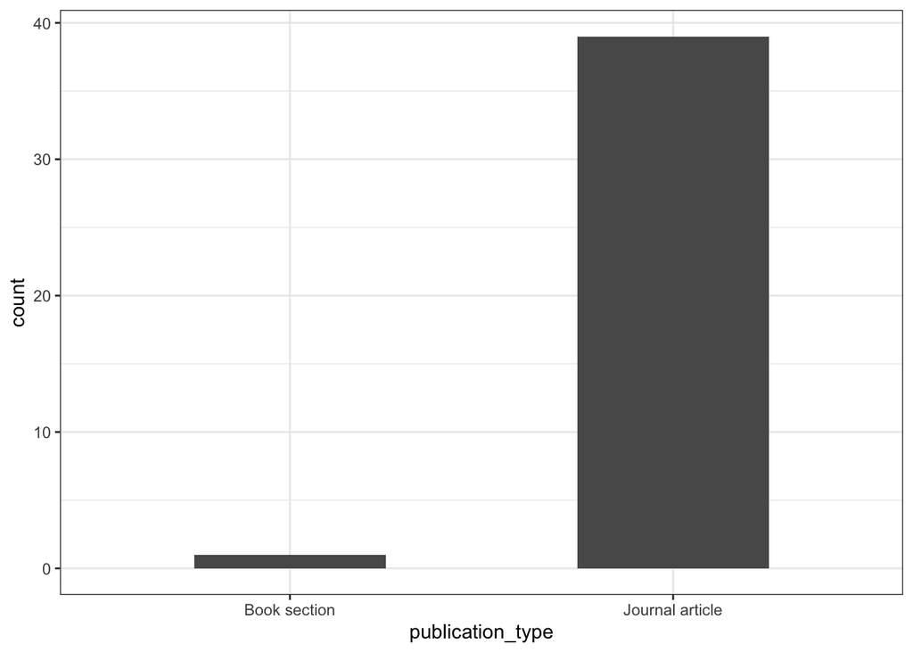

**Publication year**

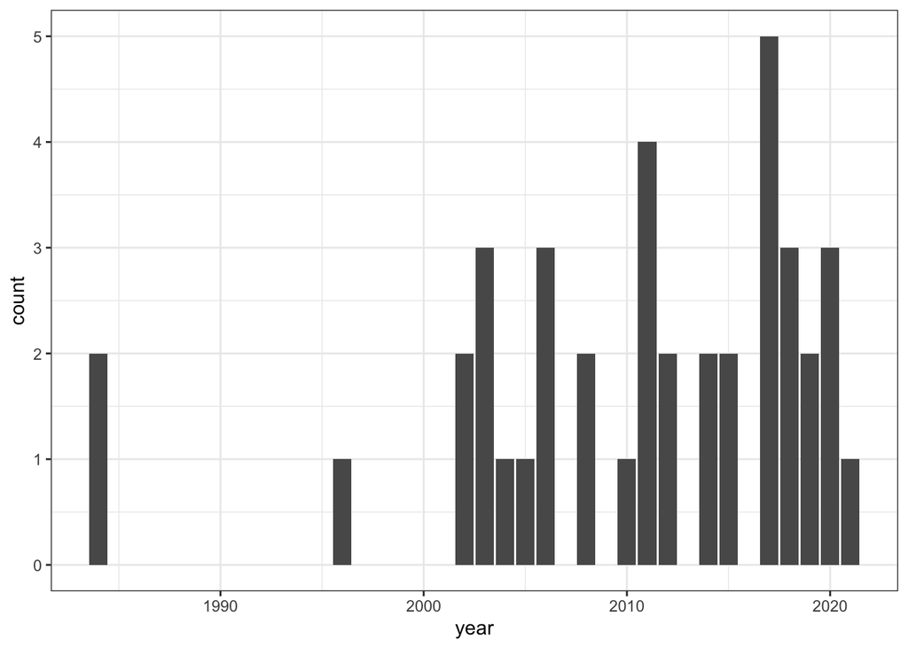

**Sampling locations**

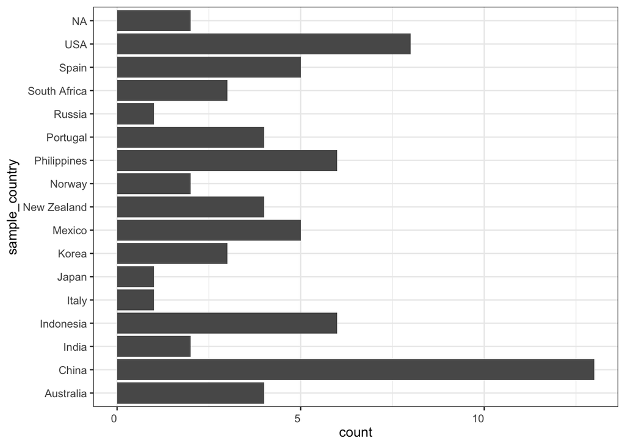

*– ANNOTATION: Carmen would you know how to adjust the count per country in ENV by publication and not by the total of countries registered in the column* sample_country*? –*

**Species type**

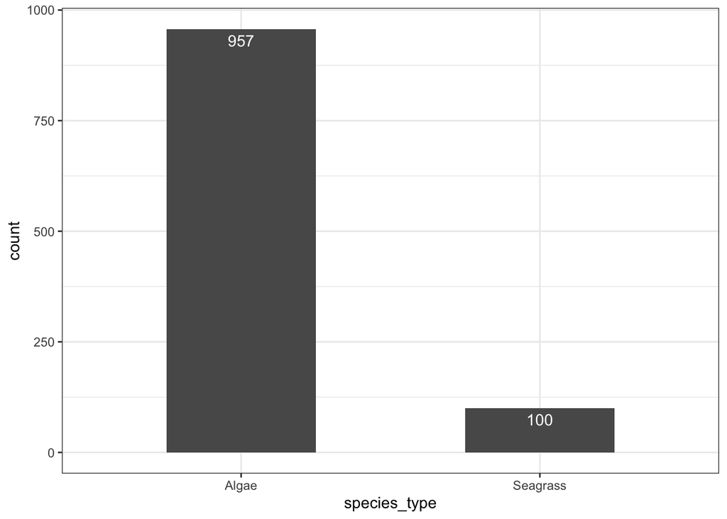

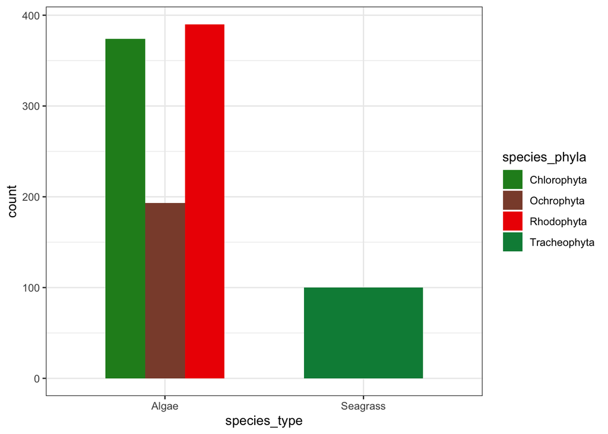

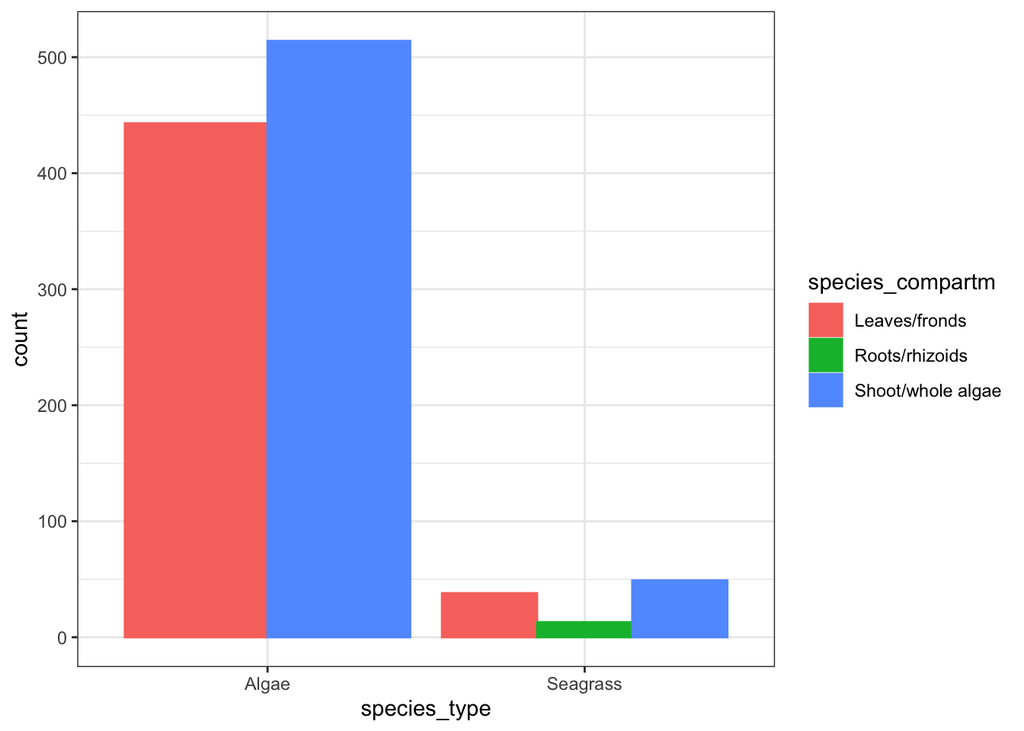

**Composition of registered uptake rate values**

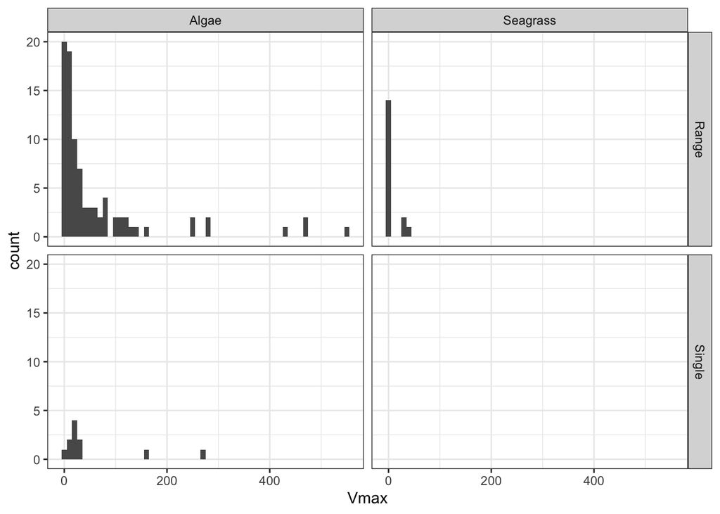

##### **Range Vmax**

**by species type**

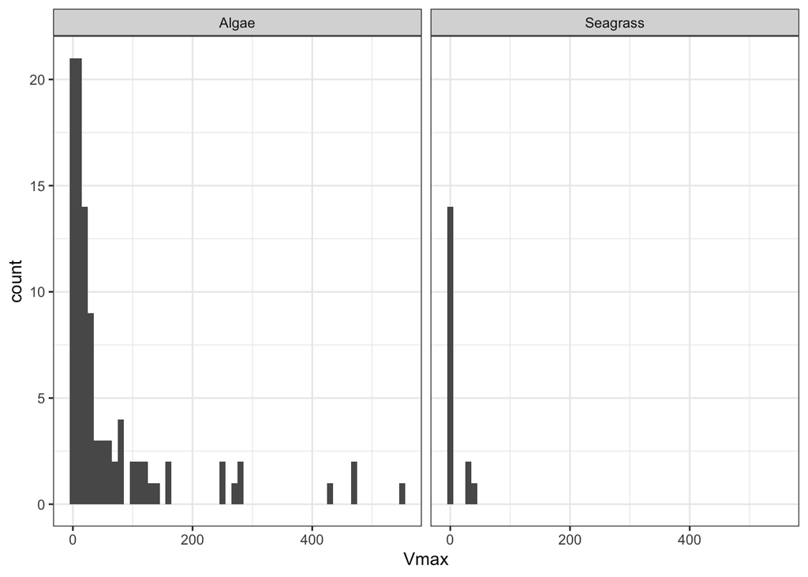

**by species type & compartment**

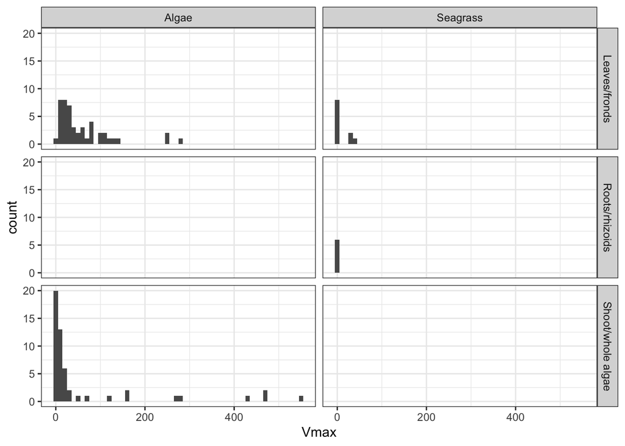

**by species type & temperature**

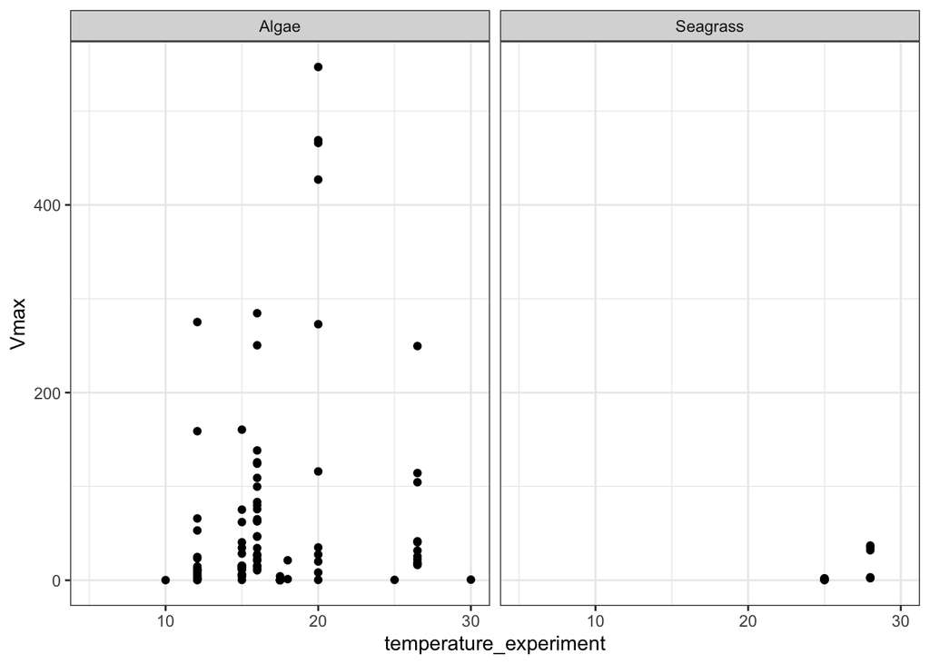

**by species type & nutrient**

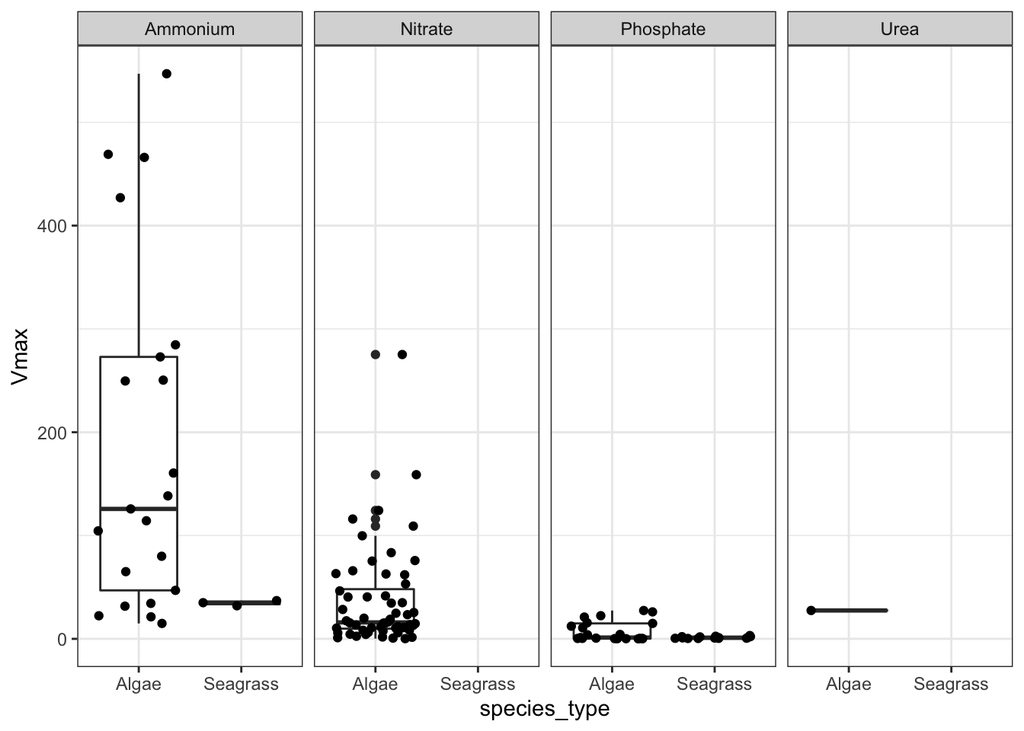

**by species type**

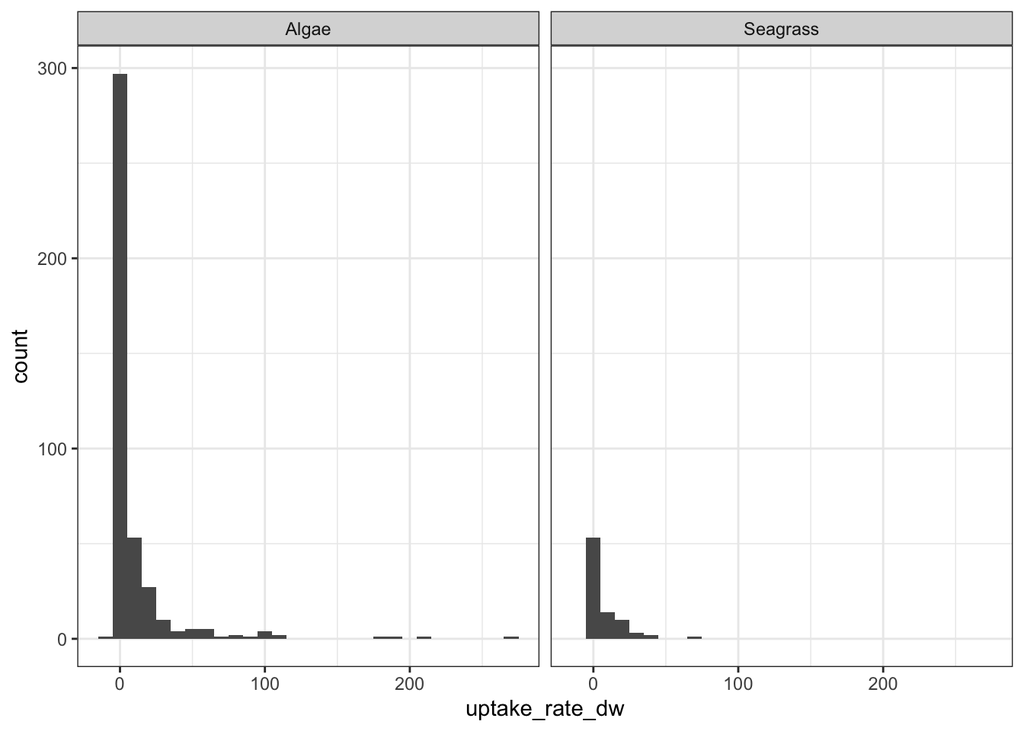

**by species type & compartment**

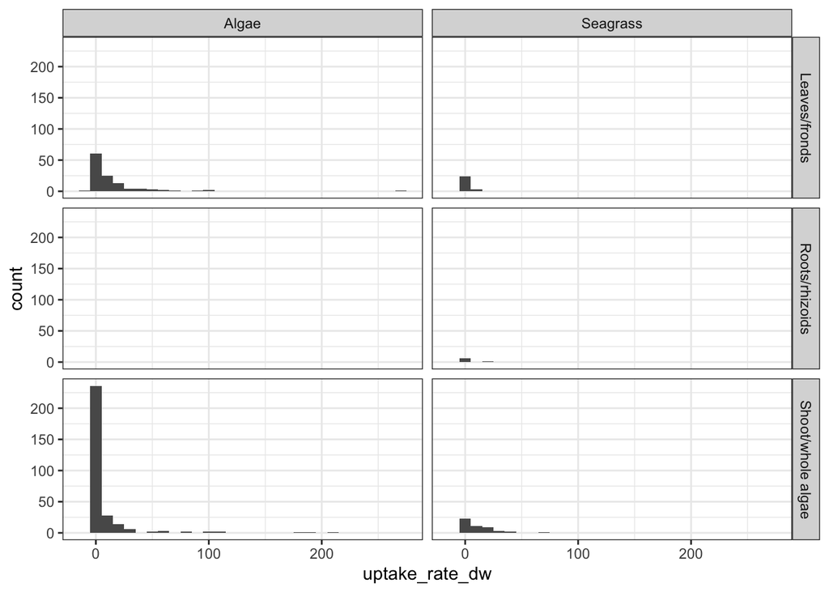

**by Internally controlled phase / Surge uptake**

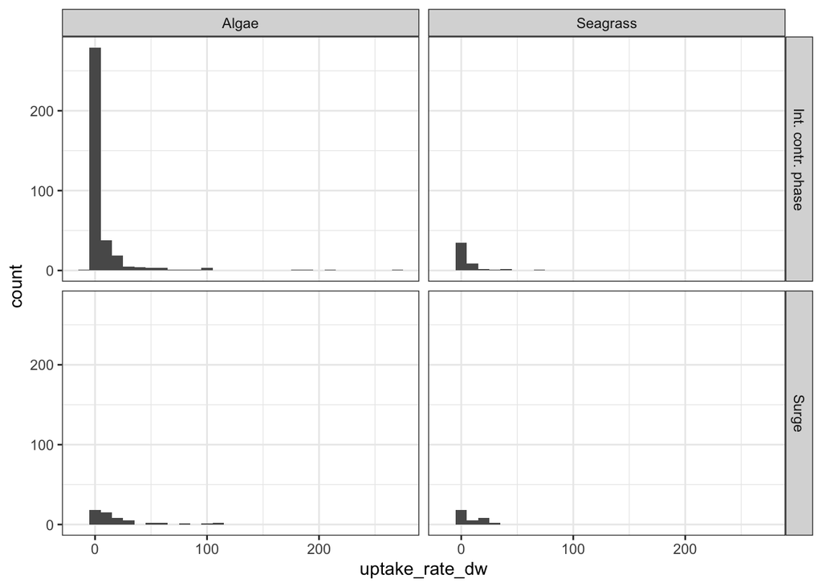

**by species type & temperature**

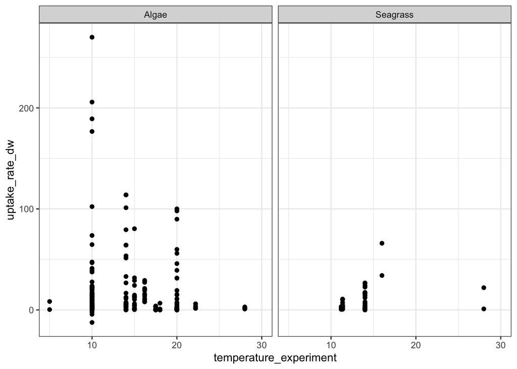

**by species type & nutrient**

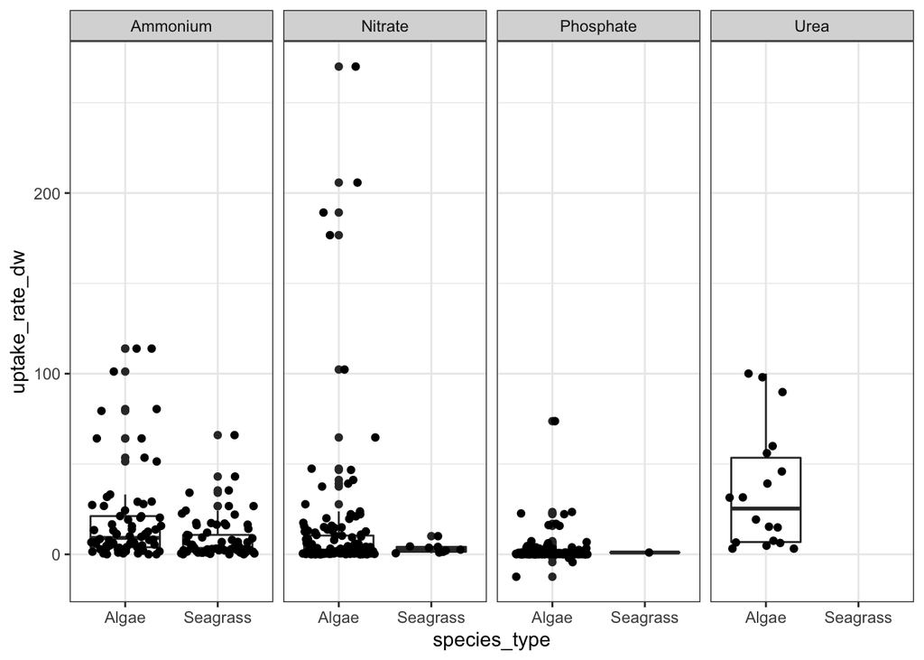